# Final Project: Recipe Generator Web App - Eat Your Veggies!

final project

Author

Gianna Pedroza, Neomi Goodman, Narayanan Kannan

Published

March 21, 2024

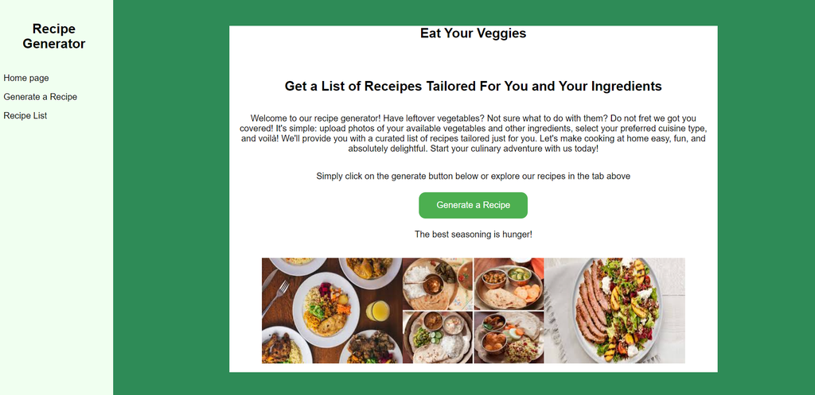

# Introduction

The goal of this project was to create a web application that allows users to discover new recipes based on the produce they have in their fridge. Users can upload images of their available produce and select their preferred cuisine. The application then uses a machine learning model to identify the ingredients from the images and compares them with a dataset of recipes. The website subsequently displays recipes from the chosen cuisine that match the identified ingredients, ranked from most to least matching. This application aims to prevent food waste and provide an opportunity for users to explore new cultures and cuisines.

This web application can be particularly beneficial to college students, like us, who are looking to save money. Many college students have limited budgets and may not have much cooking experience. By using this application, they can easily find recipes that match the ingredients they already have, reducing the need to buy more food. This not only helps to minimize food waste but also saves money that would otherwise be spent on unused ingredients. Moreover, the application’s ability to suggest recipes from different cuisines introduces users to a variety of dishes they might not have tried before. This could potentially save them money on dining out, as they can recreate these dishes at home. Furthermore, learning to cook diverse recipes can be a valuable skill that continues to save money in the long run.

The project requires several tasks to be completed. First, web scraping is needed to gather different recipes from various cuisines from all recipes. Additionally, images of different ingredients need to be web-scraped to train our model. Second, research and implementation of an advanced image classification model are necessary to recognize the different ingredients in the images uploaded by the user. Finally, a web application needs to be developed where users can upload their images and receive recipe recommendations.

Along the way, some changes were made to the initial plan. The focus was narrowed down to produce because there are too many possible ingredients that a user could upload, and it is challenging to web scrape many pictures of the same thing. Additionally, the database of recipes was limited to around 2000 to simplify the recommendation algorithm. These changes were necessary to ensure the feasibility and effectiveness of the application.

#### The functions and code used throughout the project can be found here: https://github.com/Nkannan12/Project-16B-GNN

# Part 1: Web Scraping

## I. Recipes

One of the first steps for this project is scraping a a dataset of recipes in order to recommend recipes to the user of the web app. We chose to scrape the recipes from AllRecipes.com because it specifically has a cuisines page that lists 49 different cuisines, and each recipe page has a detailed list of ingredients. One downfall of scraping this page that we noticed later on was that some common cuisines are missing from the main page, such as Mexican cuisine. However, we chose to keep the database to only these recipes in order to simplify the recommendation system since the other pages do not order the recipes by cuisine which we wanted to be one of the determining factors for recipe recommendation.

Furthermore, choosing an appropriate webscraper was also important for this task. We used BeautifulSoup which is a Python library that is specifically designed for parsing HTML and XML documents, making it ideal for web scraping. Additionally, it provides simple methods and code for navigating, searching, and modifying a parse tree. BeautifulSoup also allows for direct scraping within a notebook rather than needing to define separate Python file, like with Proxy. Working within a notebook simplifies debugging and makes it easier to run the code.

This is a simple overview of how the web scraper function scrape_allREcipes_cuisines() scrapes the page: - Step 1: Scrape through the main cuisine page and make a dataframe of all of the cuisines and their URLs. - Step 2: Loop through the list and scrape the cuisine URLs for recipe URLs and make a new dataframe with the cuisine type, recipe name, and recipe page URL. - Step 3: Loop through the new list and scrape the recipe pages for the ingredient lists and add them to the list defined in the previous step.

```
def scrape_allRecipes_cuisines():
  """
  Scrapes recipe data from Allrecipes.com based on different cuisines.

  Returns:
  pandas.DataFrame: DataFrame containing the scraped recipe information including Name, URL, Cuisine, and Ingredients.
  """

  # URL of the page listing all cuisines on Allrecipes.com
  url = 'https://www.allrecipes.com/cuisine-a-z-6740455'
  result = requests.get(url)
  doc = BeautifulSoup(result.text, "html.parser")
  cuisines = doc.select('ul.loc.mntl-link-list a')

  # Send a GET request to the page listing all cuisines
  cuisine_dict = {}
  for link in cuisines:
      cuisine = link.get_text(strip=True)
      url = link['href']
      cuisine_dict[cuisine] = url

  # Parse the HTML content of the page
  df = pd.DataFrame(list(cuisine_dict.items()), columns=['Cuisine', 'URL'])

  # Create an empty list to store recipe information
  recipes_data = []

  # Iterate over rows in the cuisine DataFrame
  for index, row in df.iterrows():
      cuisine_url = row['URL']
      cuisine = df['Cuisine'][index]
      result = requests.get(cuisine_url)
      doc = BeautifulSoup(result.text, 'html.parser')

      # {'class': 'comp mntl-card-list-items mntl-document-card mntl-card card--image-top card card--no-image'}
      # Extract information for each recipe
      recipe_info1 = doc.find_all('a', {'class': 'comp mntl-card-list-items mntl-document-card mntl-card card card--no-image'})
      recipe_info2 = doc.find_all('a', {'class': 'comp mntl-card-list-items mntl-document-card mntl-card card--image-top card card--no-image'})
      recipe_info = recipe_info1 + recipe_info2

```

[output cut: 27 more lines]

```
                          if ingredient and quantity and unit:
                              ingredient_text = f"{quantity.text.strip()} {unit.text.strip()} {ingredient.text.strip()}"
                              ingredients_list.append(ingredient_text)

              # Append recipe information to the list
              recipes_data.append({
                  'Name': name,
                  'URL': url,
                  'Cuisine': cuisine,
                  'Ingredients': ingredients_list,
              })

  # Create a DataFrame from the list of recipes
  recipes_df = pd.DataFrame(recipes_data)
  return recipes_df
```

The function scrape_allRecipes_cuisines() is designed to gather recipe data from Allrecipes.com cuisine page. It operates by first accessing a URL listing various cuisines on the website. It then extracts the names and corresponding URLs of these cuisines. Subsequently, for each cuisine, the function accesses its specific URL to retrieve recipe information. It identifies recipe details such as name and URL by parsing the HTML content. Upon obtaining a recipe’s URL, it accesses the individual recipe page to extract the ingredients list. The function then compiles all gathered data into a structured format, returning a DataFrame containing recipe names, URLs, associated cuisines, and ingredients lists.

It moves through the pages as shown in the order bellow:

1. All Cuisines Page:

[figure not shown]

2. Specific Cuisine Page

[figure not shown]

3. Recipe Page:

[figure not shown]

By running this function we produce a dataset like this:

|  | Name | URL | Cuisine | Ingredients |
| --- | --- | --- | --- | --- |
| 0 | Best Vinegar Coleslaw | https://www.allrecipes.com/recipe/59318/amish-... | Amish and Mennonite | ['1 large head cabbage, cored and finely shred... |
| 1 | Pennsylvania Dutch Pickled Beets and Eggs | https://www.allrecipes.com/recipe/13743/pennsy... | Amish and Mennonite | ['8 large eggs', '2 (15 ounce) cans whole pick... |
| 2 | Amish Macaroni Salad | https://www.allrecipes.com/recipe/74915/amish-... | Amish and Mennonite | ['2 cups uncooked elbow macaroni', '3 large ha... |
| 3 | Amish Friendship Bread Starter | https://www.allrecipes.com/recipe/7063/amish-f... | Amish and Mennonite | ['1 (.25 ounce) package active dry yeast', '¼ ... |
| 4 | My Amish Friend's Caramel Corn | https://www.allrecipes.com/recipe/74950/my-ami... | Amish and Mennonite | ['7 quarts plain popped popcorn', '2 cups dry ... |
| ... | ... | ... | ... | ... |
| 2316 | Vietnamese Grilled Pork Skewers | https://www.allrecipes.com/recipe/261122/vietn... | Vietnamese | ['1 pound pork belly, cubed', '1 fresh red ch... |
| 2317 | Goi Ga (Vietnamese Chicken and Cabbage Salad) | https://www.allrecipes.com/recipe/271155/goi-g... | Vietnamese | ['4 skinless cooked chicken breasts, shredded... |
| 2318 | Vietnamese Fresh Spring Rolls | https://www.allrecipes.com/recipe/24239/vietna... | Vietnamese | ['2 ounces rice vermicelli', '8 rice wrappers... |
| 2319 | Pho (Vietnamese Noodle Soup) | https://www.allrecipes.com/recipe/228443/authe... | Vietnamese | ['4 pounds beef soup bones (shank and knee)', ... |
| 2320 | Vietnamese Grilled Lemongrass Chicken | https://www.allrecipes.com/recipe/241607/vietn... | Vietnamese | ['2 tablespoons canola oil', '2 tablespoons fi... |

2321 rows × 4 columns

Unfortunately the ingrediants lists are not organized in a good way, so we need to isolate key ingrediants that are common in many recipes. For the machine learning model we are trying to concentrate on produce, so this list will contain more produce than anything else. Additionally, to simplify the machine learning model we will not be including the measurements of the ingrediants because it is a lot harder to train a model to also recognize how much of an ingredient is in an image.

First, we need to remove any punctuation from the string and then seacrch for the key words. To do all of this we will be using the functions remove_punctuation(text) and find_key_ingredients(df, key_ingredients). find_key_ingredients compares the each item from the key_ingredients list to the string to find if each word is in the string. For some of the ingredients there can be errors, such as ‘corn starch’ gets recognized as only ‘corn,’ so some if statements are implemented to try and prevent this mistake.

```
def remove_punctuation(text):
  '''
  - Removes the punctuation from the string of recipe ingredients
  - Input: string of ingredients
  - Output: the cleaned string
  '''
  translator = str.maketrans('', '', string.punctuation)
  return text.translate(translator)

def find_key_ingredients(df, key_ingredients):
  '''
  - Compares the lists of ingredients and creates a new column in the dataframe
    with a list of key ingredients for each recipe
  - Input: dataframe of recipes, list of key ingredients
  - Output: dataframe with new column of key ingredients
  '''

  # Function to check if any key ingredient is found in a list of ingredients
  def find_word_in_string(text):
    '''
    - Finds key ingredients in ingredient string
    - Input: text from ingredient column of df
    - Output: List of key ingredients found in ingredient column
    '''
    R = []
    for i in key_ingredients:
      if i in text:
        # a lot of recipes use corn starch and corn flour
        if i == 'corn' and ('corn starch' in text or 'corn flour' in text):
          break;
        R.append(i)
        # Sometimes only need one egg
        if i == 'eggs' and 'egg' in text and 'eggs' not in R:
          R.append(i)
    return R

  # Remove punctuation
  df['Ingredients'] = df['Ingredients'].apply(remove_punctuation)

  # Find key ingredients in each row
  df['key_ingredients'] = df['Ingredients'].apply(find_word_in_string)
  return df
```

After running these function on the recipe dataframe we get a new dataframe with a column for key ingredients:

```python
cleaned_df
```

|  | Name | URL | Cuisine | Ingredients | key_ingredients |
| --- | --- | --- | --- | --- | --- |
| 0 | Best Vinegar Coleslaw | https://www.allrecipes.com/recipe/59318/amish-... | Amish and Mennonite | 1 large head cabbage cored and finely shredded... | ['cabbage', 'celery', 'onion', 'sugar'] |
| 1 | Pennsylvania Dutch Pickled Beets and Eggs | https://www.allrecipes.com/recipe/13743/pennsy... | Amish and Mennonite | 8 large eggs 2 15 ounce cans whole pickled bee... | ['onion', 'beet', 'eggs', 'sugar'] |
| 2 | Amish Macaroni Salad | https://www.allrecipes.com/recipe/74915/amish-... | Amish and Mennonite | 2 cups uncooked elbow macaroni 3 large hardcoo... | ['celery', 'onion', 'bell pepper', 'eggs', 'su... |
| 3 | Amish Friendship Bread Starter | https://www.allrecipes.com/recipe/7063/amish-f... | Amish and Mennonite | 1 25 ounce package active dry yeast ¼ cup warm... | ['milk', 'flour', 'sugar'] |
| 4 | My Amish Friend's Caramel Corn | https://www.allrecipes.com/recipe/74950/my-ami... | Amish and Mennonite | 7 quarts plain popped popcorn 2 cups dry roast... | ['corn', 'sugar'] |
| ... | ... | ... | ... | ... | ... |
| 2316 | Vietnamese Grilled Pork Skewers | https://www.allrecipes.com/recipe/261122/vietn... | Vietnamese | 1 pound pork belly cubed 1 fresh red chile pe... | ['garlic', 'pork', 'sugar'] |
| 2317 | Goi Ga (Vietnamese Chicken and Cabbage Salad) | https://www.allrecipes.com/recipe/271155/goi-g... | Vietnamese | 4 skinless cooked chicken breasts shredded 1 ... | ['cabbage', 'cilantro', 'onion', 'carrot', 'ch... |
| 2318 | Vietnamese Fresh Spring Rolls | https://www.allrecipes.com/recipe/24239/vietna... | Vietnamese | 2 ounces rice vermicelli 8 rice wrappers 85 i... | ['cilantro', 'lettuce', 'rice'] |
| 2319 | Pho (Vietnamese Noodle Soup) | https://www.allrecipes.com/recipe/228443/authe... | Vietnamese | 4 pounds beef soup bones shank and knee 1 medi... | ['cilantro', 'garlic', 'onion', 'rice', 'beef'] |
| 2320 | Vietnamese Grilled Lemongrass Chicken | https://www.allrecipes.com/recipe/241607/vietn... | Vietnamese | 2 tablespoons canola oil 2 tablespoons finely ... | ['garlic', 'chicken', 'sugar'] |

2321 rows × 5 columns

This is our final dataset that we will be using to compare with the results of the model and to recommend recipes. The functions used in this section can be found in *recipe_manip.py*.

## II. Images for Ingredients

The web scraping model I created to gather images of ingredients from Google Images uses both BeautifulSoup and Selenium, which are used for parsing HTML and automating web interactions. By using Selenium, and web driver like geckodriver for FireFox of chromedriver for Google Chrome, the script is able to load pages by scrolling to the end, ensuring that all images are loaded before the HTML is parsed by BeautifulSoup. Additionally, Selenium allows you to interact with elements on the page, which I used to clicking on each thumbnail to access the URLs of the corresponding images.

The *main* function initializes a web driver object and prompts the user for inputs including a list of keywords, the desired number of images to download for each keyword, and the name of the file to save the downloaded images. It also creates a new file if the specified one does not already exist in the directory. Subsequently, for each keyword provided by the user, the script generates a Google Images URL and calls the *scrape_images* function to extract the URLs of the images before proceeding to download them using the *download_image* function.

The *scrape_images* function is responsible for extracting image URLs from the provided Google Images URL. It utilizes Selenium to scroll through the webpage, ensuring all images are loaded, and then parses the HTML using BeautifulSoup. Thumbnails of images are identified and clicked to access the full-sized image URLs. These URLs are collected and returned as a set.

The *download_image* function handles the downloading and saving of images. It makes a request to the provided image URL and retrieves the image content. The content is then processed, ensuring it is in a usable format. The image is then saved as a JPEG file in the specified download path with the provided file name. This ensures that the images are successfully downloaded and stored in files designated to the ingredient classes for classification with the model later on.

To be able to run the code in the terminal or in a notebook, a web driver exicutable file must be stored within the same directory as the py file. This is also where the ingredient files will be downloaded.

```
def main():
    wd = webdriver.Chrome()
    data = input('Enter your search keyword: ')
    data_list = data.split(", ")

    num_images = int(input('Enter the number of images you want: '))
    file_name = input('Enter file location: ')

    if not os.path.exists(file_name):
        os.mkdir(file_name)

    count = 0
    for i in data_list:
        search_url = Google_Image + 'q=' + i #'q=' because its a query
        print(search_url)
        urls = scrape_images(search_url, wd, 1, num_images)
        print(f"Found {len(urls)}")

        for j, url in enumerate(urls):
            download_image(file_name + "/", url, str(count) + ".jpg")
            count += 1

        print("Success!")

    print("Complete!")
    wd.quit()

def scrape_images(initial_url, wd, delay, max_images):
    url = initial_url
    wd.get(url)

    # scroll height of webpage
    last_height = wd.execute_script("return document.body.scrollHeight")
    while True:
        wd.execute_script("window.scrollTo(0, document.body.scrollHeight);")    # The driver scrolls down the webpage here.
        time.sleep(8)
        new_height = wd.execute_script("return document.body.scrollHeight")
        if new_height == last_height:   # Breaks here if the driver reached the bottom of the webpage (when it cannot scroll down anymore).
            break
        last_height = new_height        # If the driver failed to scroll to the bottom of the webpage, the current scroll height is recorded. Following, it is compared to the scroll height in the next iteration of the loop to decide if the driver reached the bottom of the webpage or not.
```

[output cut: 42 more lines]

```
        image = Image.open(image_file)
    except (IOError, OSError) as e:
        print(f"Failed to open image file - {e}")
        return  # Return without attempting to process the image further

    # Convert image to RGB mode
    image = image.convert('RGB')

    file_path = os.path.join(download_path, file_name)
    try:
        with open(file_path, "wb") as f:
            image.save(f, "JPEG")
        print(f"Downloaded: {file_name}")
    except Exception as e:
        print(f"Failed to save image - {e}")
```

Unfortunately, despite Selenium allowing us to scroll to the bottom of the page, the Google Images page only loads around 400 images for a given search word. Therefore, to get a decent amount of images for training we need to input multiple key words for the same ingredient.

For example, for the ingredient onion, there are many different types of onions so we can make a list of these and input them when prompted: yellow onion, white onion, sweet onion, red onion, shallots, onion raw. Additionally, for certain produce or ingredients often when you look them up they come up cooked, to prevent this with many of the broader ingredients you should add ‘raw’ to the key frase.

[figure not shown]

Alternatively, **name** is defined in the py file so you can run this in the terminal by calling “python image_scraper.py”

Below is what shows up during each step of the web scraping of the image URLs: 1. Scrolling to the end of the page and parsing HTML:

[figure not shown]

2. Clicking on each thumbnail and parsing HTML for image URLs:

[figure not shown]

In total, we were able to web scrape around 1000 images for 20 ingredients: Tomatoes, Potatoes, Zucchini, Broccoli, Atrichoke, Beans, Onion, Asparagus, Green Onion, Cabbage, Lentils, Garlic, Bell Peppers, Chili Peppers, Corn, Carrots, Mushrooms, Cherries, Apples, Rice.

We were not able to scrape more than this due to a few different issues. In order to fully load each page we had to allow time for it to pause between clicking and scrolling, so it took a long time to download a good amount of images for each ingredient. Additionally, the webscraper would often stop scraping randomly, most likely due to connection issues with the web driver and sometimes it would find zero items on the page.

# Part 2: The Image Classification Model

## I. Implementation of the Model

The machine learning aspect of our project entailed the implementation of a CNN in pytorch. After researching many different models, and weighing the pros and cons of each architecture, we settled on using a Resnet to carry out image classification. While we had the option to utilize a pretrained model taken from the torchvision database, we felt that it would be better to implement and train our own rendition of the network. This allowed for minute adjustments to layer functions, such as changing the filter size in a convolution, or removing negligible operations to counteract overfitting. The code itself is quite complex. Let’s walk through the actual Resnet class:

```python
class ResNet(nn.Module):
    def __init__(self, block, num_block, num_classes=100,num_channel=3):
        """Initializes the ResNet model.

        Args:
            block: Basic block or bottleneck block.
            num_block (list): List containing the number of blocks for each layer.
            num_classes (int): Number of output classes.
            num_channel (int): Number of input channels, default is 3.
        """
        super().__init__()
        self.in_channels = DIM
        self.conv1 = nn.Sequential(
          nn.Conv2d(num_channel, DIM, kernel_size=3, padding=1, bias=False),
          nn.BatchNorm2d(DIM),
          nn.ReLU(inplace=True))
        self.conv2_x = self._make_layer(block, DIM, num_block[0], 1)
        self.conv3_x = self._make_layer(block, DIM*2, num_block[1], 2)
        self.conv4_x = self._make_layer(block, DIM*4, num_block[2], 2)
        self.conv5_x = self._make_layer(block, DIM*8, num_block[3], 2)
        self.avg_pool = nn.AdaptiveAvgPool2d((1, 1))
        self.fc = nn.Linear(DIM*8 * block.expansion, num_classes)
        self.sigmoid = nn.Sigmoid()
```

This is just a snippet of the code that goes into creating a Resnet. The model starts out with a simple 2D convolution followed by a batch normalization and ReLU activation. Here, `num_channels` refers to the number of color channels in the input image (three for all our data) and `DIM` the number of output channels after the convolution is processed (`DIM` is variable, but we find a value of `64` works best). Then, we proceed to the meat of the architecture, utilizing a complex function called `_make_layer()` (definition not pictured) that is used to create a model “layer” consisting of a variable number of convolutions, batch normalizations, max pools, and activations, all depending on the type and number of “blocks” specified. Currently, we don’t need to worry about the explicit definition of a block – it’s quite involved, so it suffices to understand that they’re used as the framework of a layer in the model. After this constructor, model operations are put into motion using a feed-forward function:

```python
def forward(self, x):
  """Forward pass of the ResNet model.

    Args:
      x (torch.Tensor): Input tensor.

    Returns:
      torch.Tensor: Output tensor.
  """
  output = self.conv1(x)
  output = self.conv2_x(output)
  output = self.conv3_x(output)
  output = self.conv4_x(output)
  output = self.conv5_x(output)
  output = self.avg_pool(output)
  output = output.view(output.size(0), -1)
  output = self.fc(output)

  return self.sigmoid(output)
```

Data is fed through each layer (as outlined above) and its class probability distribution is returned using the sigmoid activation function. We use a Resnet18:

```python
def resnet18(num_classes,num_channel):
  """ returns a ResNet 18 object
  """
  return ResNet(BasicBlock, [2, 2, 2, 2],num_classes,num_channel)
```

as our main model, but by adjusting the block type and number, we can also possibly return a Resnet34, or Resnet50, all the way up to a Resnet152 (here, the number associated with a Resnet can be thought of as the number of layers in the model). This concludes the construction of our model – now we’re ready to create our dataset!

## II: Dataset Creation

In order to train, we must first create a dataset from which our model can learn from. Depending on how you store your training images, you can write a funciton to retrieve data in the form of numpy arrays. Our data was stored in a directory containing subdirectories of a given class to partition the set of different tyes of ingredients. To create numpy arrays of the images and their corresponding labels, we utilized the following:

```python
def load_images_and_labels(parent_folder, target_size=(150,150)):
  """Returns image data in form of a numpy array

  args:
    parent_folder: folder containing classes of images to move through sequentially
    target_size: size of resulting images in image array
  """
  images = []
  labels = []
  class_mapping = {"beans" : 0, "bell_pepper" : 1, "potato" : 2, "tomato" : 3}

  for class_folder in os.listdir(parent_folder):
    class_path = os.path.join(parent_folder, class_folder)
    if os.path.isdir(class_path) and class_folder in class_mapping:
      label = class_mapping[class_folder]
      for image_file in os.listdir(class_path):
        image_path = os.path.join(class_path, image_file)
        try:
          image = PIL.Image.open(image_path)
          if image is not None:
            if image.mode != 'RGB':
              image = image.convert('RGB')
            image = image.resize(target_size)
            images.append(image)
            labels.append(label)
            except Exception as e:
              print(f'Error reading image {image_path}: {e}')

  return np.array(images), np.array(labels)
```

This function iterates through each file and adds the images to python using PIL, then appends each image to a list called images, as well as its label (corresponding to the stated mapping) to a list called labels. At the end, a numpy array version of both these lists is returned. Using these, we can then create a pytorch dataset:

```python
  class Ingredients(Dataset):
    """Class creating pytorch dataset from images and their labels.

    Args:
        images (list): List of images.
        labels (list): List of corresponding labels.
        transform (callable, optional): Augmentation of the images.

    Attributes:
        images (list): List of images.
        labels (list): List of corresponding labels.
        transform (callable, optional): Augmentation of the images.

    Methods:
        __len__(self): Returns the number of samples in the dataset.
        __getitem__(self, idx): Retrieves the item at the given index.
    """
    def __init__(self, images, labels, transform=None):
        """Initializes the Ingredients dataset.

        Args:
            images (list): List of images.
            labels (list): List of corresponding labels.
            transform (callable, optional): Augmentation of the images.
        """
        self.images = images
        self.labels = labels
        self.transform = transform

    def __len__(self):
        """Returns the number of samples in the dataset.

        Returns:
            int: Number of samples in the dataset.
        """
        return len(self.images)

    def __getitem__(self, idx):
        """Retrieves the item at the given index.

        Args:
            idx (int): Index of the item to retrieve.

        Returns:
            tuple: A tuple containing the image and its corresponding label.
        """
        image = self.images[idx]
        image = PIL.Image.fromarray(image)
        label = self.labels[idx]
        if self.transform:
            image = self.transform(image)
        return image, label
```

Every pytorch dataset is a class inheriting from the dataset class (which you’ll have to import through `torchvision`) and needs to define the following three functions: a constructor (`__init__`), `__len__()`, and `__getitem__()`. The constructor records the data, `__len__` returns the length of the dataset, and `__getitem__` returns an image-label combo at an index of the set. Once we’ve created our dataset, there are multiple steps we would like to take to process our data. For one, we’d like to change the pixel values of our images to live in the range [-1,1] from the standard [0,255], done through the following:

```python
def preprocess(images_arr):
  """Preprocess an array of images.

    Args:
        images_arr (numpy.ndarray): Array of images to be preprocessed.

    Returns:
        numpy.ndarray: Preprocessed array of images, pixel values between -1 and 1.
  """
  images_arr = images_arr.astype(np.float32)
  images_arr = images_arr/255.0
  images_arr = (images_arr * 2.0) - 1.0

  return images_arr
```

In this function, we convert each image to a 32-bit float and then dilate the channels to fit within the desired interval. Additionally, we have written a function to find the mean and standard deviation across each channel:

```python
def normalization_vals(images_arr):
  """Calculate mean and standard deviation values for normalizing an array of images.

    Args:
        images_arr (numpy.ndarray): Array of images for which to calculate normalization values.

    Returns:
        tuple: A tuple containing the mean and standard deviation values for each channel.
  """
  means = np.mean(images_arr, axis=(0,1,2))
  stds = np.std(images_arr, axis=(0,1,2))
  means = tuple(means)
  stds = tuple(stds)
  return means, stds
```

These values will be used to normalize the pixel values of our training set. With all this, we are now ready to begin training.

## III. Training the Model

This part is relatively simple. The whole process is contained in one file, `main.py`, which imports useful functions as defined in other files. Here is main:

```python
import torch
import torch.optim as optim
# from torchinfo import summary

from logger import Logger
from train import run_epoch
from resnet import resnet14, resnet18, resnet34, resnet50
from data_loader import get_data
from test import run_test

torch.manual_seed(0)

EPOCHS = 200
EARLY_STOP = 5
LR = 0.1
MOMENTUM = 0.9
WEIGHT_DECAY = 0.0005 # 0.0005 test
VAL_SPLIT = 0.1

model_save_path = f'./model_logs/Ingredients1'

log = Logger()
log.set_logger(f'{model_save_path}.log')

device = torch.device("cuda" if torch.cuda.is_available() else "cpu")
train_loader, val_loader, test_loader, num_classes, num_channels = get_data(VAL_SPLIT)
model = resnet18(num_classes, num_channels)
optimizer = optim.SGD(model.parameters(), LR, MOMENTUM, weight_decay=WEIGHT_DECAY)
# scheduler = torch.optim.lr_scheduler.CosineAnnealingLR(optimizer, T_max=200)
scheduler = torch.optim.lr_scheduler.StepLR(optimizer, step_size=20, gamma=0.1)

run_epoch(model, train_loader, val_loader, optimizer, scheduler, EPOCHS, EARLY_STOP, f'{model_save_path}.pth', device, log)
accuracy = run_test(model, test_loader, device, f"{model_save_path}.pth")
log.logger.info("Accuracy: {:.10f}".format(accuracy))
```

Of note are `get_data()`, `run_epoch()`, and `run_test()`. The former is defined in another file, `data_loader.py`, and is as follows:

```python
def get_data(val_split=0.5):
    """Prepares DataLoader instances for training, validation, and testing splits of an image dataset.

    Parameters:
    - val_split (float, optional): Proportion of the training set to use for validation. Default is 0.5.

    Returns:
    - Tuple[DataLoader, DataLoader, DataLoader, int, int]: A tuple containing DataLoader instances for the
      training, validation, and test datasets, the number of unique labels in the dataset, and the number 3,
      whose specific meaning may depend on context (e.g., number of color channels).
    """
    parent_folder = "/content/drive/MyDrive/proj_files/ingredients/ingredients"
    images, labels = load_images_and_labels(parent_folder)
    preprocess(images)
    transform = transforms.Compose([
        transforms.RandomHorizontalFlip(),
        transforms.RandomResizedCrop(32),
        transforms.ToTensor(),
        transforms.Normalize((0.38046584, 0.10854615, -0.13485776), (0.5249659, 0.59474176, 0.6634378))
    ])

    dataset = Ingredients(images, labels, transform)

    batch_size = 64 # change to appropriate value for dataset in use

    dataset_size = len(dataset)
    indices = list(range(dataset_size))
    train_test_split = int(np.floor(0.8 * dataset_size))
    train_val_split = int(np.floor(val_split * dataset_size))

    np.random.shuffle(indices)

    train_idx, test_idx = indices[train_test_split:], indices[:train_test_split]
    val_idx = train_idx[:train_val_split]

    train_loader = DataLoader(dataset,
                              batch_size=batch_size,
                              sampler=SubsetRandomSampler(train_idx),
                              num_workers=4)

    test_loader = DataLoader(dataset,
                             batch_size=batch_size,
                             sampler=SubsetRandomSampler(test_idx),
                             num_workers=4)

    val_loader = DataLoader(dataset,
                            batch_size=batch_size,
                            sampler=SubsetRandomSampler(val_idx),
                            num_workers=4)

    return train_loader, val_loader, test_loader, len(np.unique(labels)), 3
```

It begins by identifying the parent directory in which all our data is located (you will have to change this to depending on where your images are located). Then it utilizes the preprocessing functions we defined above. Next, we define a dataset based on the preprocessed image data, and split this dataset into a training set, validation set, and test set. We then create an iterator of sorts called a `DataLoader` that allows us to effectively load data in batches to train the model. We create three separate data loaders, one for our training set, one for our valiadation set, and one for our test set. These, in addition to the number of classes and color channels in the data, are returned and further used in our main function. Thus, the data pipeline portion of the process has been completed. Now let’s define the actual training algorithm. The function `run_epoch()` is as follows:

```python
def run_epoch(model:torch.nn.Module, train_loader:torch.utils.data.DataLoader, val_loader:torch.utils.data.DataLoader, optimizer, scheduler, epochs:int, early_stop:int, model_save_path:str, device:torch.device, log, loading=False):
    """Run training and validation for the given number of epochs.

    Args:
        model (torch.nn.Module): The model.
        train_loader (torch.utils.data.DataLoader): DataLoader for training data.
        val_loader (torch.utils.data.DataLoader): DataLoader for validation data.
        optimizer: The optimizer to update the model's parameters.
        scheduler: Learning rate scheduler.
        epochs (int): Number of epochs for training.
        early_stop (int): Number of epochs to wait before early stopping if validation loss doesn't improve.
        model_save_path (str): Path to save the best model.
        device (torch.device): Device to be used for training (cuda or cpu).
        log: Logger object for logging.
        loading (bool): Flag indicating whether to load a pre-trained model. Default is False.

    Returns:
        None
    """
    train_losses = []
    val_losses = []
    if loading==True:
        model.load_state_dict(torch.load(model_save_path))
        log.logger.info("-------------Model Loaded------------")

    best_loss=0
    #curr_early_stop = early_stop
    model.to(device)
    for epoch in range(epochs):
        train_loss = train(model, train_loader, optimizer, device)
        val_loss = val(model, val_loader, device)
        scheduler.step()

        log.logger.info((f"Epoch: {epoch+1} - loss: {train_loss:.10f} - test_loss: {val_loss:.10f}"))

        train_losses.append(train_loss)
        val_losses.append(val_loss)

        if epoch == 0:
            best_loss=val_loss
        if val_loss<=best_loss:
            torch.save(model.state_dict(), model_save_path)
            best_loss=val_loss
            log.logger.info("-------- Save Best Model! --------")
```

This function utilizes both our training and validation data loaders. We defined functions for training and validation (train and val, respectively) that implement the classic backpropogation process. Additionally, we include a learning rate scheduler to help boost training results. Logger is used to create files that streamline the access and view of our results. Using validation loss as our metric, we save every model that is an improvement over the current best model. If needed, one could easily implement an early stopping system (in fact, our own early stop code is commented out of the original file on github), but based off our research, which involved looking into the processes outlined in the original Resnet research paper, it seemed best to evaluate the model of a full period of 200 epochs. Lastly, we look at the `run_test()` function, which is again, relatively simple:

```python
def run_test(model, test_loader, device, model_save_path):
    """Run testing on the test data using the trained model.

    Args:
        model (torch.nn.Module): The trained model.
        test_loader (torch.utils.data.DataLoader): DataLoader containing the test data.
        device (torch.device): The device to be used for testing (cuda or cpu).
        model_save_path (str): Path to the saved model.

    Returns:
        float: Accuracy achieved by the model on the test data.
    """
    model.load_state_dict(torch.load(model_save_path))
    model.to(device)
    model.eval()

    all_labels = []
    all_predictions = []

    with torch.no_grad():
        for images, labels in test_loader:
            images, labels = images.to(device), labels.to(device)
            outputs = model(images)
            _, predictions = torch.max(outputs, 1)
            all_labels.extend(labels.cpu().numpy())
            all_predictions.extend(predictions.cpu().numpy())

    accuracy = accuracy_score(all_labels, all_predictions)

    return accuracy
```

Here, we use the test_loader to run through the dataset one more time, evaluating it using our final, fully trained model and calculating accuracy using scikit-learn’s accuray algorithm. We trained our model on a small subset of ingredients, which resulted in an accuracy score of around 70%. This score should improve immensley when a large number and variety of images is used as training data, unfortunately, we were unable to achieve this premier model due to a lack of resources. Our dataset creation function is quite itensive. Thus, when trying to load our set, both google colab and jupyter lab would run out of GPU RAM. Given the proper resources, it would be more than possible to produce a fully trained model on an expansive dataset. Still, we produced a more than adequate network using only a small subset. It’s training results are visualized below:

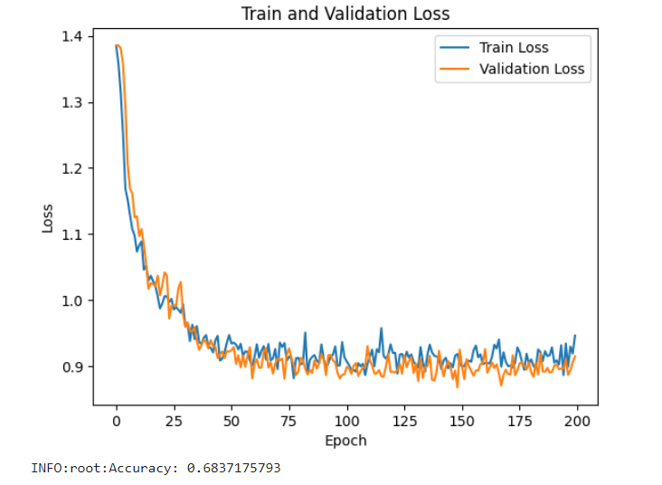

image.png

# Part 3: The Web Application

Once we have scrapped a recipe website, created a data frame with images, and trained our model we are ready to start creating the website and implementing our functions to get the site running. For the website, we have 3 main parts (you can even refer to them as pages. First, we have to establish a home page that explains how the website works and invites users to start generating recipes. The second step is to create a page that allows for the image inputs by the users and generates a slit of recipes. Lastly, in case the user wants to roam freely through the database of recipes we created a recipe list page in which users can simply choose their preferred cuisine and receive a list of recipes.

Let’s dive deeper and explore how to build each page!

## I. Home Page

While creating the home page itself simple involved design we also first had to establish the HTML code to set up the Web APP. To start off we created a a base.html and a main.html. Main pourpose of the base.html is to provides a structured layout with a navigation bar and placeholders for dynamic content. The navigation bar ks able to naviage between the three pages”:

- Home page: Links to the main page of the application. The url_for(‘main’) function dynamically generates the URL to the view function named main.
- Generate a Recipe: Links to the page where users can generate recipes. The url_for(‘generate’) generates the URL to the generate view function.
- Recipe List: Links to a page displaying a list of recipes. The url_for(‘receipe_page’) (note the typo in ‘recipe’) generates the URL to the receipe_page view function.

[figure not shown]

image.png

Below the main.html sets up the structure of the mian page. we used img src to present three images and imporve the appreace of our model but most importantly we added a button called “Generate a Receipe”. The style of the button is added at style.css. The picture below depics how our home page looks like. As you can see you can navigate to the generate a recipe page both through the button in the middle or through the navigation bar. Below the image we will dive into how we formulated the generate function.

[figure not shown]

image.png

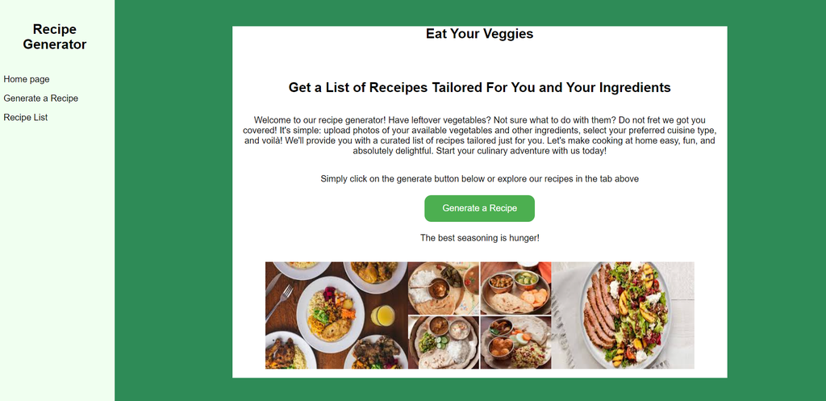

In order to be able to ensure that the website is functioning and is interactive with users, we had to implement the generate function. When navigating to the generate page users and asked to choose their preferred cuisine and upload pictures of their products. To be able to process the data the user inputs and to be able to provide them with the appropriate recipes, we created the gen_recipe() function. Below is the code for when a user goes to the home page and when a user goes to the generate a recipe page. But more importantly, it also includes our recipe function which can intake the data process it and redirect users to the page with the recipe list.

The function has both a GET and a POST request lets quickly explore when occure under each:

- If the request method is GET (e.g., when a user navigates to /generate/ directly), the server responds by rendering and returning the generate2.html template. This page ( presented below the function code) allows users to input data (like selecting a cuisine or uploading images) needed to generate a recipe.
- If the method is POST (e.g., when a user submits a form on generate2.html), the server tries to process the submitted data, to do so it needs to retrieves the selected cusine from the datafarme.

Once the data is retived it intializes our pre-trained deep learning model (resnet18) configured for a 4-class classification problem (the classes being different ingredients). The function then loads the model weights from a specified file and prepares a series of image transformations (e.g., flipping, cropping, normalization) to apply to the uploaded images. For each uploaded image, it applies the transformations which can be seen when the in the function at the transform= transforms.Compose section.

The code converts the image to a tensor, and then uses the model to predict the ingredient class.Each predicted ingredient is then added to a list. After processing all images, it redirects the user to the recipe_results route, passing along the selected cuisine and the list of predicted ingredients. In case there is an error occuring during the processing of the POST request the error handling is included to ensure it catches the exception and re-renders the generate2.html template with an error indicator.

The end of the functions redirects the user to a new page (recipe_results) where recipes based on the identified ingredients and selected cuisine are shown. This is done by passing the cuisine type and the list of identified ingredients as arguments to the url_for function, which generates the appropriate URL for the redirect.

```python
@app.route('/')
def main():
    return render_template('main_better.html')

@app.route('/generate/', methods=['POST', 'GET'])
def generate():
    """Handle the generation of ingredient predictions based on uploaded images.

    If the request method is GET, renders the 'generate2.html' template.
    If the request method is POST, processes the uploaded images, predicts ingredients,
    and redirects to the 'recipe_results' function.

    Returns:
        Response: Rendered template or redirection to 'recipe_results' function.
    """
    if request.method == 'GET':
        return render_template('generate2.html')
    else:
        try:
            cuisine = request.form.get('cuisine')
            classes = ['beans', 'bell_pepper', 'potato', 'tomato']
            model = resnet18(4, 3) # model trained on small dataset
            model.load_state_dict(torch.load('model/model_logs/Ingredients8.pth', map_location='cpu'))

            #set to eval for testing
            model.eval()
            files = request.files.getlist('images[]')
            transform = transforms.Compose([
                transforms.RandomHorizontalFlip(),
                transforms.RandomResizedCrop(32),
                transforms.ToTensor(),
                transforms.Normalize((0.38046584, 0.10854615, -0.13485776), (0.5249659, 0.59474176, 0.6634378))
            ])
            ingredients = []
            images = []
            for file in files:
                try:
                    image = Image.open(file)
                    if image is not None:
                        if image.mode != 'RGB':
                            image = image.convert('RGB')
                        # image = image.resize((150,150))
                        image = np.array(image)
                        images.append(image)
                except Exception as e:
                    print(f'Error reading file {file}: {e}')

            # allow for the transform to work on pil_image
            pil_images = [Image.fromarray(image) for image in images]
            transformed_images = [transform(image) for image in pil_images]
            images = torch.stack(transformed_images)

            # classify each image
            for image in images:
                # don't track gradient for efficient testing
                with torch.no_grad():
                    outputs = model(image.unsqueeze(0))
                    _, pred_class = torch.max(outputs, 1)
                    ingredient = classes[pred_class.item()]
                    ingredients.append(ingredient)

            # send list of ingredients to recipe_results function
            return redirect(url_for('recipe_results', cuisine=cuisine, ingredients=ingredients))

        except:
            return render_template('generate2.html', error=True)

@app.route('/generate/<name>')
def generate_name(name):
    return render_template('generate2.html', name=name)
```

##### The generate page where user upload their images and chose their prefred cuisine!

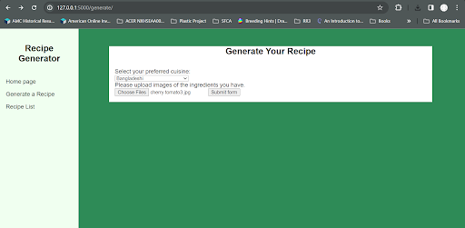

generate.png

Once the user upload the images they submit their request and are immidetaly redirected to the following page. Below the name of each receipe, we also included a short list of all the key ingredients that are need to make it easier for users to select the receipe they want.

This is when the gen_recipes function is used to produce a list of recipes with the most matched ingredients.

The gen_recipe function generates recipe recommendations based on a specified cuisine and the list of ingredients returned by the image classification model. It first reads a recipe dataset, filtering it by cuisine if provided. When a list of ingredients is provided, it further filters the dataset based on the presence of matching ingredients. The function applies different matching thresholds depending on the length of the ingredient list. Recipes with a higher number of matching ingredients are given priority. Finally, the function returns a sorted dataframe of recommended recipes tailored to the user’s cuisine and available ingredients.

```
def gen_recipe(cuisine, list_of_ingredients=None):
  '''
  - Generates recipe recommendations from the recipe dataset based off of the
    detected ingredients from user input images and prefered cuisine.
  - Input: cuisine, list of ingredients
  - Output: dataframe of recomended recipes
  '''
  link = 'https://raw.githubusercontent.com/Nkannan12/Project-16B-GNN/main/Recipes_cleaned.csv'
  df = pd.read_csv(link)

  if list_of_ingredients == None:
    cuisine_df = df[df["Cuisine"] == cuisine].copy()
    return cuisine_df
  else:
    cuisine_df = df[df["Cuisine"] == cuisine].copy()
    # Create a new column to count matching ingredients
    cuisine_df['Matched Ingredients'] = cuisine_df['key_ingredients'].apply(lambda x: sum(1 for ingredient in list_of_ingredients if ingredient in x))
    if len(list_of_ingredients) > 2:
      cuisine_df = cuisine_df[cuisine_df['Matched Ingredients'] >= 2]
    else:
      cuisine_df = cuisine_df[cuisine_df['Matched Ingredients'] >= 1]
    # Sort dataframe based on the number of matched ingredients in descending order
    cuisine_df = cuisine_df.sort_values(by='Matched Ingredients', ascending=False)

    # Reset index
    cuisine_df.reset_index(drop=True, inplace=True)

    return cuisine_df
```

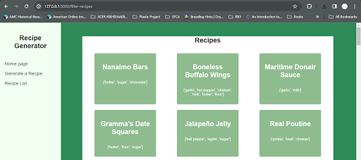

filter2.png

Once selecting a recipe the user clicks on the name of the recipe and immediately gets redirected to the recipe page where they can get the cooking instructions and list of the rest of the needed ingredients

[figure not shown]

Screenshot 2024-03-20 071406.png

## II. List of recipes

Another component of the website is the recipe list page. On this page, participants are simply able to explore the different cuisine and the recipes within them regardless of the ingredients they have.

The code from the app.py file below will present how the receipe list page work and how we navigate to the correct url of the recipe

The def filter_ recipe takes in the user selected cuisine and filter through the data farme to find the matching receipes. Lets break down the decorator and the function.

first the @app.route(‘/filter-recipes’, methods=[‘POST’]) decorator tells Flask to use the filter_recipes function as the handler for requests to the URL /filter-recipes when the HTTP method is POST.

When the create the function which runs when the POST request is made for filter-recipes. The “cuisine = request.form.get(‘cuisine’)” code extracts the value of cuisine from the form data submitted with the POST request. If cuisine is not present in the form data, None is returned instead. The next line “ingredients = None: Initializes ingredients with None” is added so when we are generating receipes we can also incldue ingredients howevere in this case users only select a cusine.

The function then calls the function gen_recipe with cuisine and ingredients as arguments. This function isreturns a collection of recommended recipes based on the provided cuisine (and potentially ingredients, if implemented).

We then convert the recommended_recipes into a list of dictionaries. Each dictionary represents a recipe, and the orient=‘records’ parameter means each row in the DataFrame is converted to a dictionary, with column names as keys.

Lastly we render the receipe result page.

```python
@app.route('/filter-recipes', methods=['POST'])
def filter_recipes():
    """Filter recipes based on selected cuisine and ingredients.

    Retrieves the selected cuisine and ingredients from the request form, then generates
    recommended recipes using the 'gen_recipe' function. Converts the recommended recipes
    into a dictionary format and renders the 'recipe_results.html' template, passing the
    recipes data.

    Returns:
        Response: Rendered template 'recipe_results.html' with recipes data.
    """
    cuisine = request.form.get('cuisine')
    ingredients = None

    recommended_recipes = gen_recipe(cuisine, ingredients)
    recipes_data = recommended_recipes.to_dict(orient='records')

    # Render the recipe_results.html template, passing the recipes data
    return render_template('recipe_results.html', recipes=recipes_data)
```

### Now that we are at the recipe results page lets examine the recipe_resulst function:

When a user accesses the /recipe_results/ URL, the application can respond to both GET and POST requests. For GET requests, it’s expected that the user has passed information through the URL’s query parameters, specifying both a type of cuisine and ingredients they’re interested in. The application checks if both pieces of information are provided; if not, it displays a message asking for both the cuisine and ingredients. If the information is present, it uses a function gen_recipe from earlier to fetch recommended recipes matching the specified criteria, converts this data into a format that can be easily used in the HTML template, and then displays it to the user on the recipe_results.html page. For POST requests, which are not explicitly handled with form data in this code, it simply displays a message encouraging the user to select a cuisine to view recipes, suggesting that the main interaction mode expected is through GET requests

```python
@app.route('/recipe_results/', methods=['GET', 'POST'])
def recipe_results():
    """Display recipe results based on selected cuisine and ingredients.

    If the request method is GET, retrieves the selected cuisine and ingredients from the request arguments,
    generates recommended recipes using the 'gen_recipe' function, converts the recommended recipes into a
    dictionary format, and renders the 'recipe_results.html' template, passing the recipes data. If either
    cuisine or ingredients is not provided, displays an error message.

    If the request method is not GET, displays a message prompting the user to select a cuisine to view recipes.

    Returns:
        Response: Rendered template 'recipe_results.html' with recipes data or an error message.
    """
    if request.method == 'GET':
        # fetch cuisine and ingredients passed form generate
        cuisine = request.args.get('cuisine')
        ingredients = request.args.get('ingredients')
        if cuisine is None or ingredients is None:
            message = "Provide both a cuisine and ingredients."
            return render_template('recipe_results.html', message=message)
        # print(cuisine + ' ' + ingredients)
        recommended_recipes = gen_recipe(cuisine, ingredients)
        # print(recommended_recipes)
        recipes_data = recommended_recipes.to_dict(orient='records')
        print(recipes_data)  # Debugging line to check data
        return render_template('recipe_results.html', recipes=recipes_data)
    else:
        message = "Please select a cuisine to view recipes."
        return render_template('recipe_results.html', message=message)

if __name__ == '__main__':
    app.run(debug=True)
```

The code below is from the receipe_results.html, it dynamically display a list of recipes on a webpage. If recipes are available, each one is presented with its name (as a clickable link to the recipe’s page) and its key ingredients. If no recipes are available, a predefined message is displayed instead.

### Lets break down how it works and what each part does:

The h1 simply displays the header of the page.

The div id=“recipes”>…</div” encloses the entire section of the code that deals with displaying the recipes or a message in case there are no recipes to display. It is important to note that the id=“recipes” attribute is used to uniquely identify this division in the document, which can be useful for styling or scripting purposes.

Next up % if recipes % is a Jinja2 conditional statement that checks if there is a recipes variable available and it has a truthy value (e.g., a non-empty list). If recipes is truthy, the block of code inside this condition is executed.

If the recipes variable exists and contains items than this lines % for recipe in recipes % , loop iterates over each item in recipes, note each item in the loop is referred to as recipe.

Inside the loop, a div class=“recipe”>…</div is defined for each recipe. Within this divsion we displays the recipe’s name and links to the recipe’s URL. The recipe.Name and recipe.URL are placeholders that get replaced with the actual name and URL of the recipe, respectively, as provided by the recipes variable. A paragraph (p) with the class “key-ingredients” that displays the key ingredients of the recipe. The recipe.key_ingredients placeholder is replaced with the actual key ingredients data. Lastly , else is executed if recipes is falsy (e.g., an empty list or None). It renders a paragraph (p) displaying a message, which is provided by the message variable. To end the if-else conditional look we use endif

[figure not shown]

Here is what the recipe list page looks like. Once users submit preferences they will be redirected to the same page as the recipe page from above. Again when clicking a recipe they will be redirected to the recipe website.

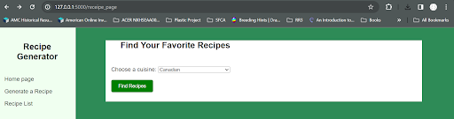

filter.png

Finally, the recommended recipes are rendered on the recipe result page for the user to explore. This page allows users to explore the recipes from different cuisines without needing to upload any images, in the case that they do not have any ingredients.

# Ethical Considerations

# Conclusion

In conclusion, our project involved three main components: web scraping, machine learning, and web app development.

For the web scraping part, we scraped a dataset of recipes from AllRecipes.com, leveraging BeautifulSoup for parsing HTML and extracting relevant information such as cuisines and ingredients. Despite some limitations, such as missing cuisines on the main page, we focused on this dataset to simplify the recommendation system based on cuisine, which was a key factor in our recipe recommendations.

In the machine learning aspect, we implemented a Convolutional Neural Network (CNN) using PyTorch, specifically a ResNet architecture, for image classification of ingredients. While pretrained models were available, we chose to train our own model to fine-tune layer functions and optimize performance. Due to resource constraints, we trained the model on a small subset of ingredients, achieving around 70% accuracy. With more extensive training data and more memory resources, we anticipate significant improvements in model performance.

Lastly, we developed a web app using Flask, consisting of three main pages: a home page explaining the website’s functionality, an image input page for generating recipe recommendations based on user-selected ingredients, and a recipe list page allowing users to explore recipes by cuisine. This cohesive integration of web scraping, machine learning, and web development resulted in a functional and user-friendly platform for recipe exploration and recommendation.

Overall, while our project faced challenges such as limited memory for trianing the model and resource constraints, we successfully demonstrated the feasibility of combining web scraping, machine learning, and web app development to create a recipe recommendation system. With further refinement and expansion, this system has the potential to offer valuable culinary insights and inspiration to users seeking recipe ideas and trying to save money.